# Transition Network Analysis (TNA) Tutorial

## 7. Patterns: Cliques

Patterns help understand behavior, identify significant structures, and describe processes in detail. Patterns form fundamental building blocks of structure and learning process dynamics. They furnish insights into behavior and learner strategies during studying or learning material interaction. Furthermore, capturing repeated consistent patterns enables theory building and generalizable inferences.

TNA supports identifying several n-clique pattern types. Network cliques comprise graph node subsets where every node pair connects directly through edges. In network terms, cliques represent tightly-knit communities, closely related entities, or interdependent nodes shaping learning unfolding.

The `cliques()` function identifies n-cliques from TNA models. Its arguments include:

- **`size`**: The clique size to search for (size=2 finds dyads, size=3 finds triads, etc.)
- **`threshold`**: The minimum edge weight required for an edge to participate in a clique

**Dyads** represent TNA's simplest patterns — transitions between two nodes. Mutual dyads (bidirectional) with high edge weights indicate strong interdependence through recurrent occurrence. For instance, consistently moving from reading materials to quiz-taking indicates strong self-evaluative strategies.

**Triads** capture more complex three-node relationships. In TNA, three-node cliques where each connects to the others in either direction indicate strong interdependent node subgroups forming a process core. Triads represent higher-order learning behavior dependencies.

We search for cliques of size 2, 3, and 4 with decreasing thresholds (larger cliques are rarer, so lower thresholds are needed):

```python
# Find cliques of size 2, 3, and 4 with decreasing thresholds
cliques_of_two   = tna.cliques(model, size=2, threshold=0.1)   # dyads
cliques_of_three = tna.cliques(model, size=3, threshold=0.05)  # triads
cliques_of_four  = tna.cliques(model, size=4, threshold=0.03)  # quads
```

```python
print(cliques_of_two)
```

```
Cliques of size 2 (threshold=0.1)
Number of cliques found: 5

Clique 1: cohesion, emotion
  cohesion: 0.027  0.116
  emotion: 0.325  0.077

Clique 2: consensus, coregulate
  consensus: 0.082  0.188
  coregulate: 0.135  0.023

Clique 3: consensus, discuss
  consensus: 0.082  0.188
  discuss: 0.321  0.195

Clique 4: consensus, plan
  consensus: 0.082  0.396
  plan: 0.290  0.374

Clique 5: discuss, emotion
  discuss: 0.195  0.106
  emotion: 0.102  0.077
```

```python
print(cliques_of_three)
```

```
Cliques of size 3 (threshold=0.05)
Number of cliques found: 3

Clique 1: consensus, coregulate, discuss
  consensus: 0.082  0.188  0.188
  coregulate: 0.135  0.023  0.274
  discuss: 0.321  0.084  0.195

Clique 2: consensus, discuss, emotion
  consensus: 0.082  0.188  0.073
  discuss: 0.321  0.195  0.106
  emotion: 0.320  0.102  0.077

Clique 3: consensus, emotion, plan
  consensus: 0.082  0.073  0.396
  emotion: 0.320  0.077  0.100
  plan: 0.290  0.147  0.374
```

```python
print(cliques_of_four)
```

```
Cliques of size 4 (threshold=0.03)
Number of cliques found: 5

Clique 1: cohesion, coregulate, discuss, emotion
  cohesion: 0.027  0.119  0.060  0.116
  coregulate: 0.036  0.023  0.274  0.172
  discuss: 0.048  0.084  0.195  0.106
  emotion: 0.325  0.034  0.102  0.077

Clique 2: cohesion, coregulate, emotion, monitor
  cohesion: 0.027  0.119  0.116  0.033
  coregulate: 0.036  0.023  0.172  0.086
  emotion: 0.325  0.034  0.077  0.036
  monitor: 0.056  0.058  0.091  0.018

Clique 3: consensus, coregulate, discuss, emotion
  consensus: 0.082  0.188  0.188  0.073
  coregulate: 0.135  0.023  0.274  0.172
  discuss: 0.321  0.084  0.195  0.106
  emotion: 0.320  0.034  0.102  0.077

Clique 4: consensus, coregulate, emotion, monitor
  consensus: 0.082  0.188  0.073  0.047
  coregulate: 0.135  0.023  0.172  0.086
  emotion: 0.320  0.034  0.077  0.036
  monitor: 0.159  0.058  0.091  0.018

Clique 5: consensus, emotion, monitor, plan
  consensus: 0.082  0.073  0.047  0.396
  emotion: 0.320  0.077  0.036  0.100
  monitor: 0.159  0.091  0.018  0.216
  plan: 0.290  0.147  0.076  0.374
```

## 8. Centralities

Centrality measures quantify the role or importance of states or events in processes. With centrality measures, researchers can rank events by their value in bridging interactions (betweenness centrality) or receiving the most transitions (in-strength centrality). Centrality measures reveal which behaviors or cognitive states prove central to learning processes — as frequent transition destinations, starting points for various actions, bridges between learning activities, or keys to spreading phenomena. Using centrality measures, researchers can identify important events to target for intervention or improvement.

Importantly, raw or absolute centrality measure values lack inherent meaning in TNA. Relative values matter instead, allowing node ranking and relative importance identification within networks.

### 8.1 Node-Level Centrality Measures

The `centralities()` function computes centrality measures using directed probabilistic process algorithms. By default, it removes loops from calculations (changeable via `loops=True`). Removing loops means all centrality computations proceed without considering self-transitioning or same-state repetition.

Available measures include:

- **OutStrength / InStrength**: Sum of outgoing/incoming transition probabilities. In pruned networks where self-loops are removed, out-strength reflects state stability — higher values indicate greater likelihood of transitioning away.
- **Closeness / InCloseness**: How quickly a state can reach (or be reached from) all other states.
- **Betweenness**: How often a state lies on shortest paths between other states, measuring its bridging role.
- **BetweennessRSP**: Betweenness based on randomized shortest paths — more appropriate for probabilistic networks.
- **Diffusion**: Measures how efficiently information or influence spreads from a state.
- **Clustering**: Local clustering coefficient reflecting the interconnectedness of a state's neighbors.

```python
# Compute all centrality measures for each state
centrality_df = tna.centralities(model)
centrality_df.round(4)
```

|  | OutStrength | InStrength | ClosenessIn | ClosenessOut | Closeness | Betweenness | BetweennessRSP | Diffusion | Clustering |
| --- | --- | --- | --- | --- | --- | --- | --- | --- | --- |
| adapt | 1.0000 | 0.3446 | 0.0083 | 0.0152 | 0.0248 | 1.0 | 1.0 | 5.5863 | 0.3370 |
| cohesion | 0.9729 | 0.8116 | 0.0138 | 0.0124 | 0.0265 | 0.0 | 19.0 | 5.2086 | 0.2996 |
| consensus | 0.9180 | 2.6672 | 0.0351 | 0.0125 | 0.0383 | 30.0 | 103.0 | 4.6597 | 0.1608 |
| coregulate | 0.9766 | 0.5666 | 0.0155 | 0.0150 | 0.0210 | 0.0 | 27.0 | 5.1479 | 0.3058 |
| discuss | 0.8051 | 1.1882 | 0.0196 | 0.0131 | 0.0271 | 16.0 | 53.0 | 4.6276 | 0.2397 |
| emotion | 0.9232 | 0.8941 | 0.0141 | 0.0121 | 0.0231 | 5.0 | 36.0 | 5.0699 | 0.2905 |
| monitor | 0.9819 | 0.3457 | 0.0076 | 0.0137 | 0.0193 | 0.0 | 11.0 | 5.1568 | 0.2889 |
| plan | 0.6258 | 1.1938 | 0.0274 | 0.0115 | 0.0274 | 9.0 | 61.0 | 3.4875 | 0.2875 |
| synthesis | 1.0000 | 0.1915 | 0.0100 | 0.0158 | 0.0243 | 7.0 | 3.0 | 5.5825 | 0.3586 |

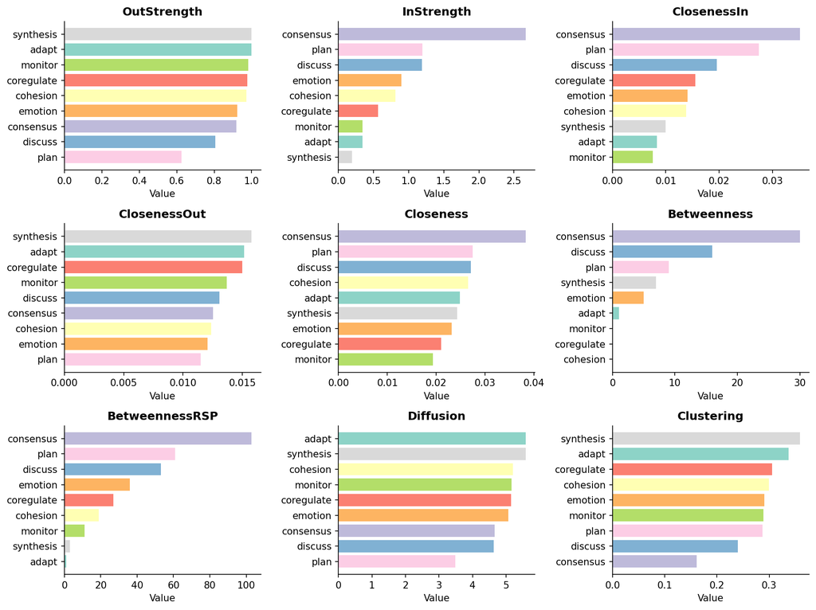

```python
# Plot centralities as faceted bar charts
tna.plot_centralities(centrality_df)
plt.show()
```